# Data 608 Assignment 1

```r
library(tidyverse)
library(ggplot2)
```

# 1 Module 1

**Principles of Data Visualization and Introduction to ggplot2**

I have provided you with data about the 5,000 fastest growing companies in the US, as compiled by Inc. magazine. lets read this in:

```r
inc <- read.csv("https://raw.githubusercontent.com/charleyferrari/CUNY_DATA_608/master/module1/Data/inc5000_data.csv", header= TRUE)
```

And lets preview this data:

```r
head(inc)
```

|  | Rank | Name | Growth_Rate | Revenue | Industry | Employees | City | State |
| --- | --- | --- | --- | --- | --- | --- | --- | --- |
| 1 | 1 | Fuhu | 421.48 | 1.179e+08 | Consumer Products & Services | 104 | El Segundo | CA |
| 2 | 2 | FederalConference.com | 248.31 | 4.960e+07 | Government Services | 51 | Dumfries | VA |
| 3 | 3 | The HCI Group | 245.45 | 2.550e+07 | Health | 132 | Jacksonville | FL |
| 4 | 4 | Bridger | 233.08 | 1.900e+09 | Energy | 50 | Addison | TX |
| 5 | 5 | DataXu | 213.37 | 8.700e+07 | Advertising & Marketing | 220 | Boston | MA |
| 6 | 6 | MileStone Community Builders | 179.38 | 4.570e+07 | Real Estate | 63 | Austin | TX |

```r
summary(inc)
```

```
##       Rank                          Name       Growth_Rate
##  Min.   :   1   (Add)ventures         :   1   Min.   :  0.340
##  1st Qu.:1252   @Properties           :   1   1st Qu.:  0.770
##  Median :2502   1-Stop Translation USA:   1   Median :  1.420
##  Mean   :2502   110 Consulting        :   1   Mean   :  4.612
##  3rd Qu.:3751   11thStreetCoffee.com  :   1   3rd Qu.:  3.290
##  Max.   :5000   123 Exteriors         :   1   Max.   :421.480
##                 (Other)               :4995
##     Revenue                                  Industry      Employees
##  Min.   :2.000e+06   IT Services                 : 733   Min.   :    1.0
##  1st Qu.:5.100e+06   Business Products & Services: 482   1st Qu.:   25.0
##  Median :1.090e+07   Advertising & Marketing     : 471   Median :   53.0
##  Mean   :4.822e+07   Health                      : 355   Mean   :  232.7
##  3rd Qu.:2.860e+07   Software                    : 342   3rd Qu.:  132.0
##  Max.   :1.010e+10   Financial Services          : 260   Max.   :66803.0
##                      (Other)                     :2358   NA's   :12
##             City          State
##  New York     : 160   CA     : 701
##  Chicago      :  90   TX     : 387
##  Austin       :  88   NY     : 311
##  Houston      :  76   VA     : 283
##  San Francisco:  75   FL     : 282
##  Atlanta      :  74   IL     : 273
##  (Other)      :4438   (Other):2764
```

Think a bit on what these summaries mean. Use the space below to add some more relevant non-visual exploratory information you think helps you understand this data:

```r
# Insert your code here, create more chunks as necessary
str(inc)
```

```
## 'data.frame':    5001 obs. of  8 variables:
##  $ Rank       : int  1 2 3 4 5 6 7 8 9 10 ...
##  $ Name       : Factor w/ 5001 levels "(Add)ventures",..: 1770 1633 4423 690 1198 2839 4733 1468 1869 4968 ...
##  $ Growth_Rate: num  421 248 245 233 213 ...
##  $ Revenue    : num  1.18e+08 4.96e+07 2.55e+07 1.90e+09 8.70e+07 ...
##  $ Industry   : Factor w/ 25 levels "Advertising & Marketing",..: 5 12 13 7 1 20 10 1 5 21 ...
##  $ Employees  : int  104 51 132 50 220 63 27 75 97 15 ...
##  $ City       : Factor w/ 1519 levels "Acton","Addison",..: 391 365 635 2 139 66 912 1179 131 1418 ...
##  $ State      : Factor w/ 52 levels "AK","AL","AR",..: 5 47 10 45 20 45 44 5 46 41 ...
```

```r
nrow(inc)
```

```
## [1] 5001
```

```r
ncol(inc)
```

```
## [1] 8
```

## 1.1 Question 1

Create a graph that shows the distribution of companies in the dataset by State (ie how many are in each state). There are a lot of States, so consider which axis you should use. This visualization is ultimately going to be consumed on a ‘portrait’ oriented screen (ie taller than wide), which should further guide your layout choices.

```r
# Answer Question 1 here

# get number of companies in each state (Count)
q1 <- inc %>%
  group_by(State) %>%
  tally(n='Count') %>%
  arrange(desc(Count))
q1
```

| State | Count |
| --- | --- |
| CA | 701 |
| TX | 387 |
| NY | 311 |
| VA | 283 |
| FL | 282 |
| IL | 273 |
| GA | 212 |
| OH | 186 |
| MA | 182 |
| PA | 164 |

[output cut: 42 more lines]

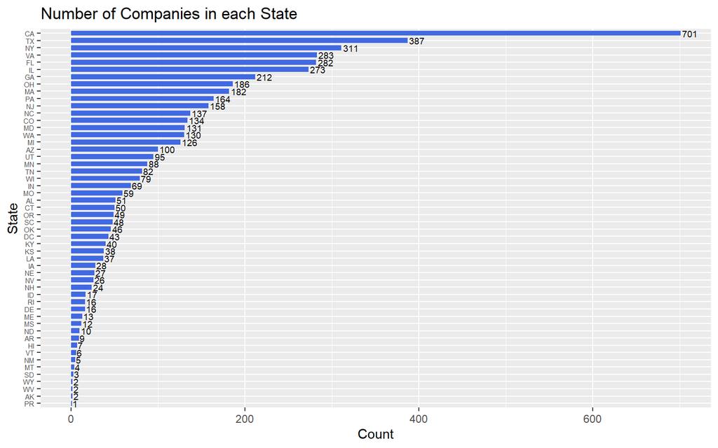

```r
ggplot(q1, aes(x=reorder(State, Count), y=Count)) +
  geom_bar(stat="identity", width=0.7, fill = "royalblue") +
  geom_text(aes(label=Count), size=2.5, hjust=-0.1) +
  labs(title = "Number of Companies in each State", x="State", y="Count") +
  theme(axis.text.y = element_text(size = 5.5)) +
  coord_flip()
```

## 1.2 Quesiton 2

Lets dig in on the state with the 3rd most companies in the data set. Imagine you work for the state and are interested in how many people are employed by companies in different industries. Create a plot that shows the average and/or median employment by industry for companies in this state (only use cases with full data, use R’s `complete.cases()` function.) In addition to this, your graph should show how variable the ranges are, and you should deal with outliers.

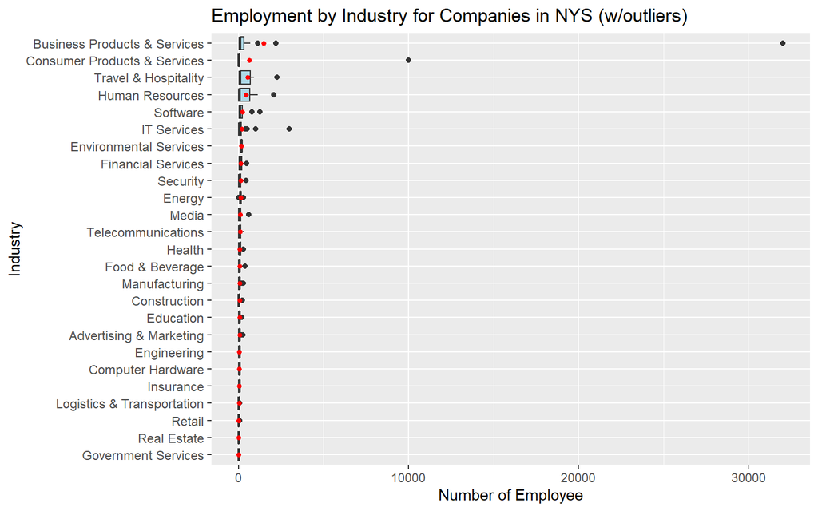

```r
# Answer Question 2 here

# get full data and NY State only
q2 <- inc[complete.cases(inc) & inc$State=="NY", ]

# first graph: with outliers
ggplot(q2, aes(reorder(Industry, Employees), Employees)) +
  geom_boxplot(fill="lightblue") +
  stat_summary(fun.y=mean, geom="point", shape=20, size=2, color="red", fill="red") +
  labs(title="Employment by Industry for Companies in NYS (w/outliers)", x="Industry", y="Number of Employee") +
  theme(axis.text.y = element_text(size = 9)) +
  coord_flip()
```

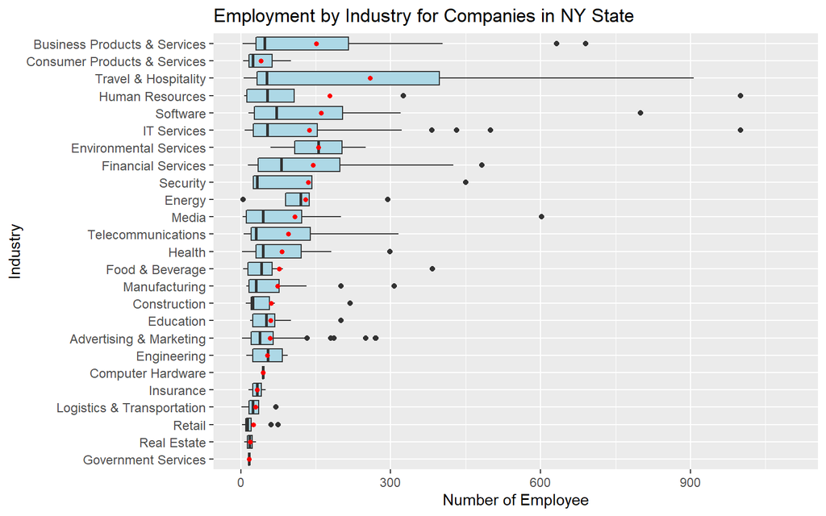

```r
# second graph: without outliers
ggplot(q2, aes(reorder(Industry, Employees), Employees)) +
  scale_y_continuous(limits=c(0,1100)) +
  geom_boxplot(fill="lightblue") +
  stat_summary(fun.y=mean, geom="point", shape=20, size=2, color="red", fill="red") +
  labs(title="Employment by Industry for Companies in NY State", x="Industry", y="Number of Employee") +
  theme(axis.text.y = element_text(size = 9)) +
  coord_flip()
```

*The second boxplot graph above shows the employment by industry for companies in NY State, where the red dots are the mean of number of employee of each industry.*

## 1.3 Question 3

Now imagine you work for an investor and want to see which industries generate the most revenue per employee. Create a chart that makes this information clear. Once again, the distribution per industry should be shown.

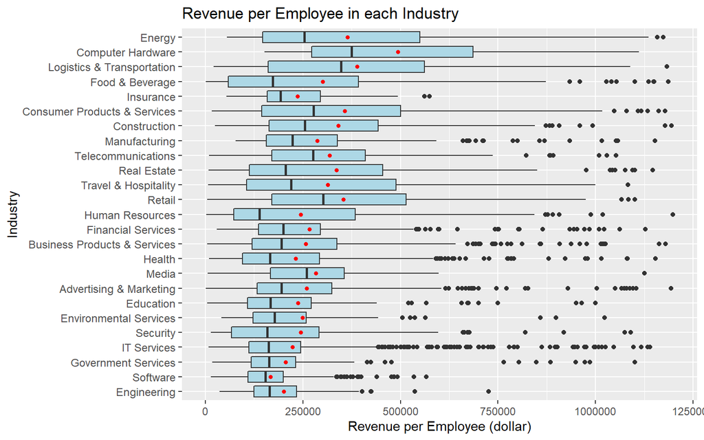

```r
# Answer Question 3 here

# get full data, then the revenue per employee (rev_emp)
q3 <- inc[complete.cases(inc),] %>%
  mutate(rev_emp = Revenue/Employees)

ggplot(q3, aes(reorder(Industry, rev_emp), y=rev_emp)) +
  scale_y_continuous(limits=c(0,1200000)) +
  geom_boxplot(fill="lightblue") +
  stat_summary(fun.y=mean, geom="point", shape=20, size=2, color="red", fill="red") +
  labs(title="Revenue per Employee in each Industry", x="Industry", y="Revenue per Employee (dollar)") +
  theme(axis.text.y = element_text(size = 9)) +
  coord_flip()
```